# Health and Economic Impacts of Severe Weather Events in the USA

## Synopsis

In this report we aim to analyse the impacts of storms and other severe weather events, which can cause both public health and economic problems for communities and municipalities. This project involves exploring the U.S. National Oceanic and Atmospheric Administration’s (NOAA) storm database.

We found out that tornadoes are the events with the most fatalities, followed by Excessive Heat.

We also found out that Flood is what causes more economic damage to the United States, followed by Hurricane Typhoons and Tornadoes.

## Data Processing

The analysis was performed in the National Oceanic and Atmospheric Administration’s (NOAA) storm database.

1. [CSV data](https://d396qusza40orc.cloudfront.net/repdata%2Fdata%2FStormData.csv.bz2)
2. [Data documentation](https://d396qusza40orc.cloudfront.net/repdata%2Fpeer2_doc%2Fpd01016005curr.pdf)
3. [Events FAQ Page](https://d396qusza40orc.cloudfront.net/repdata%2Fpeer2_doc%2FNCDC%20Storm%20Events-FAQ%20Page.pdf)

We must first download the CSV file and then load it (it can take a few minutes):

```r
  setwd("~/Dev/datasciencecoursera/course5/")
  download.file("https://d396qusza40orc.cloudfront.net/repdata%2Fdata%2FStormData.csv.bz2", "StormData.csv.bz2")
  storm.data <- read.csv("StormData.csv.bz2")
```

Let’s take a look at the data:

```r
  dim(storm.data)
```

```
## [1] 902297     37
```

```r
  summary(storm.data)
```

```
##     STATE__                  BGN_DATE             BGN_TIME
##  Min.   : 1.0   5/25/2011 0:00:00:  1202   12:00:00 AM: 10163
##  1st Qu.:19.0   4/27/2011 0:00:00:  1193   06:00:00 PM:  7350
##  Median :30.0   6/9/2011 0:00:00 :  1030   04:00:00 PM:  7261
##  Mean   :31.2   5/30/2004 0:00:00:  1016   05:00:00 PM:  6891
##  3rd Qu.:45.0   4/4/2011 0:00:00 :  1009   12:00:00 PM:  6703
##  Max.   :95.0   4/2/2006 0:00:00 :   981   03:00:00 PM:  6700
##                 (Other)          :895866   (Other)    :857229
##    TIME_ZONE          COUNTY           COUNTYNAME         STATE
##  CST    :547493   Min.   :  0.0   JEFFERSON :  7840   TX     : 83728
##  EST    :245558   1st Qu.: 31.0   WASHINGTON:  7603   KS     : 53440
##  MST    : 68390   Median : 75.0   JACKSON   :  6660   OK     : 46802
##  PST    : 28302   Mean   :100.6   FRANKLIN  :  6256   MO     : 35648
##  AST    :  6360   3rd Qu.:131.0   LINCOLN   :  5937   IA     : 31069
##  HST    :  2563   Max.   :873.0   MADISON   :  5632   NE     : 30271
##  (Other):  3631                   (Other)   :862369   (Other):621339
##                EVTYPE         BGN_RANGE           BGN_AZI
##  HAIL             :288661   Min.   :   0.000          :547332
##  TSTM WIND        :219940   1st Qu.:   0.000   N      : 86752
##  THUNDERSTORM WIND: 82563   Median :   0.000   W      : 38446
##  TORNADO          : 60652   Mean   :   1.484   S      : 37558
##  FLASH FLOOD      : 54277   3rd Qu.:   1.000   E      : 33178
##  FLOOD            : 25326   Max.   :3749.000   NW     : 24041
##  (Other)          :170878                      (Other):134990
##          BGN_LOCATI                  END_DATE             END_TIME
##               :287743                    :243411              :238978
##  COUNTYWIDE   : 19680   4/27/2011 0:00:00:  1214   06:00:00 PM:  9802
##  Countywide   :   993   5/25/2011 0:00:00:  1196   05:00:00 PM:  8314
##  SPRINGFIELD  :   843   6/9/2011 0:00:00 :  1021   04:00:00 PM:  8104
##  SOUTH PORTION:   810   4/4/2011 0:00:00 :  1007   12:00:00 PM:  7483
##  NORTH PORTION:   784   5/30/2004 0:00:00:   998   11:59:00 PM:  7184
##  (Other)      :591444   (Other)          :653450   (Other)    :622432
##    COUNTY_END COUNTYENDN       END_RANGE           END_AZI
##  Min.   :0    Mode:logical   Min.   :  0.0000          :724837
##  1st Qu.:0    NA's:902297    1st Qu.:  0.0000   N      : 28082
##  Median :0                   Median :  0.0000   S      : 22510
##  Mean   :0                   Mean   :  0.9862   W      : 20119
##  3rd Qu.:0                   3rd Qu.:  0.0000   E      : 20047
##  Max.   :0                   Max.   :925.0000   NE     : 14606
##                                                 (Other): 72096
```

[output cut: 41 more lines]

```
##  Min.   :   0   Min.   :-14451   Min.   :   0   Min.   :-14455
##  1st Qu.:2802   1st Qu.:  7247   1st Qu.:   0   1st Qu.:     0
##  Median :3540   Median :  8707   Median :   0   Median :     0
##  Mean   :2875   Mean   :  6940   Mean   :1452   Mean   :  3509
##  3rd Qu.:4019   3rd Qu.:  9605   3rd Qu.:3549   3rd Qu.:  8735
##  Max.   :9706   Max.   : 17124   Max.   :9706   Max.   :106220
##  NA's   :47                      NA's   :40
##                                            REMARKS           REFNUM
##                                                :287433   Min.   :     1
##                                                : 24013   1st Qu.:225575
##  Trees down.\n                                 :  1110   Median :451149
##  Several trees were blown down.\n              :   568   Mean   :451149
##  Trees were downed.\n                          :   446   3rd Qu.:676723
##  Large trees and power lines were blown down.\n:   432   Max.   :902297
##  (Other)                                       :588295
```

```r
  unique(storm.data$EVTYPE)
```

```
##   [1] TORNADO                        TSTM WIND
##   [3] HAIL                           FREEZING RAIN
##   [5] SNOW                           ICE STORM/FLASH FLOOD
##   [7] SNOW/ICE                       WINTER STORM
##   [9] HURRICANE OPAL/HIGH WINDS      THUNDERSTORM WINDS
##  [11] RECORD COLD                    HURRICANE ERIN
##  [13] HURRICANE OPAL                 HEAVY RAIN
##  [15] LIGHTNING                      THUNDERSTORM WIND
##  [17] DENSE FOG                      RIP CURRENT
##  [19] THUNDERSTORM WINS              FLASH FLOOD
##  [21] FLASH FLOODING                 HIGH WINDS
##  [23] FUNNEL CLOUD                   TORNADO F0
##  [25] THUNDERSTORM WINDS LIGHTNING   THUNDERSTORM WINDS/HAIL
##  [27] HEAT                           WIND
##  [29] LIGHTING                       HEAVY RAINS
```

[output cut: 479 more lines]

We can see that some events are written differently, mostly because of typing issues, but are actually the same (e.g. “TSTM WIND” and “THUNDERSTORM WIND”, “LIGHTING” and “LIGHTNING”, “Frost” and “FROST”).

We will normalize some of the top occurrences of them.

```r
  normalized.data <- storm.data
  length(unique(normalized.data$EVTYPE))
```

```
## [1] 985
```

First, convert everything to UPPER CASE:

```r
  normalized.data$EVTYPE <- toupper(normalized.data$EVTYPE)
  length(unique(normalized.data$EVTYPE))
```

```
## [1] 898
```

Removing unused punctuation:

```r
  normalized.data$EVTYPE <- gsub("[/[:punct:]]+", " ", normalized.data$EVTYPE)
  length(unique(normalized.data$EVTYPE))
```

```
## [1] 874
```

Merging some categories:

```r
  normalized.data[startsWith(normalized.data$EVTYPE, "TORNADO"),]$EVTYPE <- "TORNADO"
  length(unique(normalized.data$EVTYPE))
```

```
## [1] 865
```

Fixing some typos:

```r
  normalized.data[normalized.data$EVTYPE == "LIGHTING",]$EVTYPE <- "LIGHTNING"
  normalized.data[normalized.data$EVTYPE == "THUNDERSTORM WIND",]$EVTYPE <- "TSTM WIND"
  normalized.data[normalized.data$EVTYPE == "TORNDAO",]$EVTYPE <- "TORNADO"
  length(unique(normalized.data$EVTYPE))
```

```
## [1] 862
```

Removing double, leading and trailing spaces:

```r
  normalized.data$EVTYPE <- gsub("\\s+", " ", normalized.data$EVTYPE)
  normalized.data$EVTYPE <- gsub("^\\s*", "", normalized.data$EVTYPE)
  normalized.data$EVTYPE <- gsub("\\s*$", "", normalized.data$EVTYPE)
  length(unique(normalized.data$EVTYPE))
```

```
## [1] 826
```

We could process the data more, but we covered enough cases.

### Health Impacts

We now group the events to find out which ones are more impactful to the population health.

```r
  library(dplyr)
  health.impacts <- normalized.data %>%
    select(EVTYPE, INJURIES, FATALITIES) %>%
    group_by(EVTYPE) %>%
    summarise(INJURIES = sum(INJURIES), FATALITIES = sum(FATALITIES)) %>%
    arrange(desc(FATALITIES), desc(INJURIES))
```

The 5 events with more impact to health are:

```r
  head(health.impacts, 5)
```

```
## # A tibble: 5 x 3
##           EVTYPE INJURIES FATALITIES
##            <chr>    <dbl>      <dbl>
## 1        TORNADO    91364       5658
## 2 EXCESSIVE HEAT     6525       1903
## 3    FLASH FLOOD     1777        978
## 4           HEAT     2100        937
## 5      LIGHTNING     5230        817
```

### Economic Impacts

We now group the events to find out which ones are more impactful to economy.

To do that, we need to calculate how much each event costs in dollars. We use the fields `PROPDMG` and `CROPDMG`, and its exponents `PROPDMGEXP` and `CROPDMGEXP`.

We need a function to transform the exponents into a multiplier we can use to calculate:

```r
  transform_exponents <- function(exponents) {
    ALL.EXPONENTS <- list('H' = 100,
                          'K' = 1000,
                          'M' = 1000000,
                          'B' = 1000000000,
                          '0' = 0,
                          '2' = 2)
    ALL.EXPONENTS[toupper(exponents)]
  }
```

```r
  normalized.data$PROPDMG.multiplier <- transform_exponents(normalized.data$PROPDMGEXP)
```

```r
  normalized.data[normalized.data$PROPDMG.multiplier == 'NULL',]$PROPDMG.multiplier <- 0
  normalized.data$PROPDMG.multiplier <- as.numeric(normalized.data$PROPDMG.multiplier)
```

```r
  normalized.data$PROPDMG.total <- normalized.data$PROPDMG * normalized.data$PROPDMG.multiplier
```

```r
  normalized.data$CROPDMG.multiplier <- transform_exponents(normalized.data$CROPDMGEXP)
```

```r
  normalized.data[normalized.data$CROPDMG.multiplier == 'NULL',]$CROPDMG.multiplier <- 0
  normalized.data$CROPDMG.multiplier <- as.numeric(normalized.data$CROPDMG.multiplier)
```

```r
  normalized.data$CROPDMG.total <- normalized.data$CROPDMG * normalized.data$CROPDMG.multiplier
```

Then we calculate the damage:

```r
  normalized.data$TOTALDMG <- normalized.data$PROPDMG.total + normalized.data$CROPDMG.total
  economic.impacts <- normalized.data %>%
    select(EVTYPE, TOTALDMG) %>%
    group_by(EVTYPE) %>%
    summarise(TOTALDMG = sum(TOTALDMG)) %>%
    arrange(desc(TOTALDMG))
```

```r
  head(economic.impacts, 5)
```

```
## # A tibble: 5 x 2
##              EVTYPE     TOTALDMG
##               <chr>        <dbl>
## 1             FLOOD 150319678250
## 2 HURRICANE TYPHOON  71913712800
## 3           TORNADO  58959393490
## 4       STORM SURGE  43323541000
## 5              HAIL  18758221670
```

## Results

1. Across the United States, which types of events are most harmful with respect to population health?

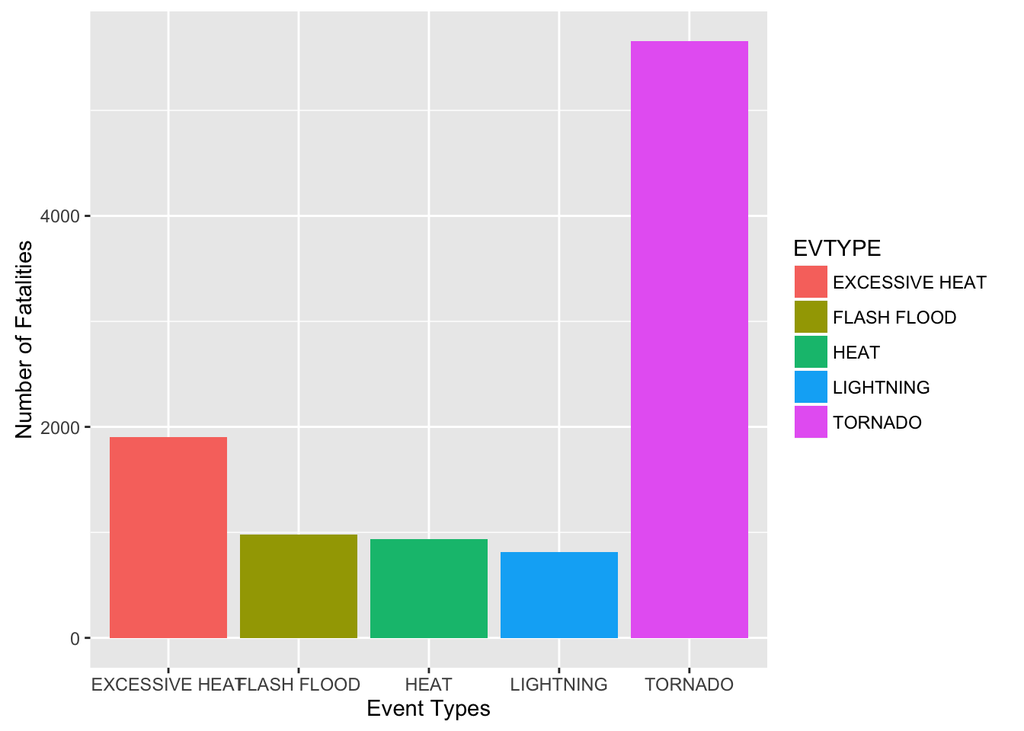

```r
  library(ggplot2)
  ggplot(data = head(health.impacts, 5),
         main = "Top 5 Health Impact Events caused by Weather in the US",
         aes(x = EVTYPE, y = FATALITIES, fill=EVTYPE)) +
    geom_bar(stat="identity") +
    xlab("Event Types") +
    ylab("Number of Fatalities")
```

Tornadoes are the most harmful events to population health, with more than 5000 fatalities.

2. Across the United States, which types of events have the greatest economic consequences?

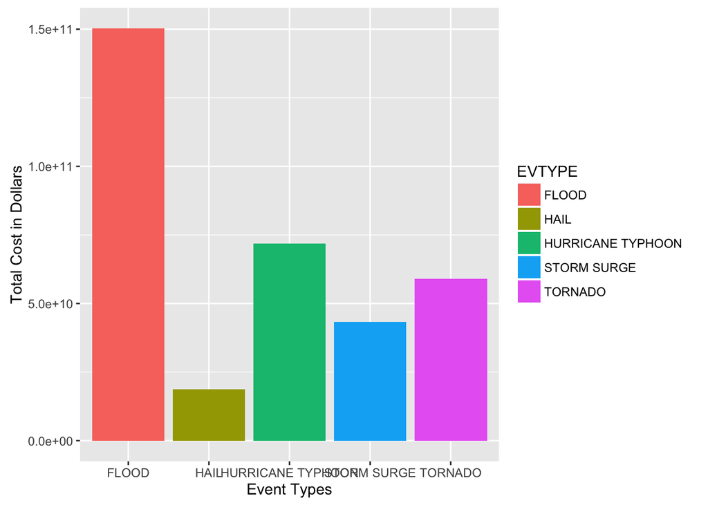

```r
  ggplot(data = head(economic.impacts, 5),
         main = "Top 5 Economic Impact Events caused by Weather in the US",
         aes(x = EVTYPE, y = TOTALDMG, fill=EVTYPE)) +
    geom_bar(stat="identity") +
    xlab("Event Types") +
    ylab("Total Cost in Dollars")
```

Flood is what causes more economic damage to the United States, followed by Hurricane Typhoons and Tornadoes.